# Mapping Malnutrition: A Spatial Analysis of Health Inequalities in India

Candidate Number: 45358

15/01/2025

**Prompt:** 2

**ChatGPT/AI disclosure statement:** I have used ChatGPT primarily to navigate through the functioning of SQL database. Specifically, I queried the AI to get codeline to save GEOJSON .png and .rds files in the database. I also used ChatGPT to refine my code in places where it was redundant and repetitive (e.g., chatgpt provided the idea of creating base_url list for state-data). Finally, I used the AI to understand the functioning of OGD API.

## 1. Understanding Malnutrition in India

#### 1.1 Scope and Challenges

India ranks 105 out of the 127 countries on the Global Hunger Index (GHI) and with it’s population of 1.43 billion, comprises 1/3rd of the world’s malnourished children. India also has the highest child wasting rate in the world at 18.7%. Despite efforts, malnutrition costs India as much as 3% of it’s GDP growth each year, making the Prime Minister Narendra Modi’s inconceivably bold claims of making India a $5 trillion economy by 2025. The key issue lies in the government’s one-size-fits-all approach towards malnutrition.

The **National Family Health Survey - 4 (2015-16)** is used to collect dristict-level population, nutrition and health data for 7 states of India. These states have the highest malnutrition rates in the country. The spatial data is fetched from **Open Street Maps (OSM) using the Nomatim API**.

#### 1.2 Code Setup

```r
#This code chunk loads all the necessary packages used throughout the report.

library("httr") #Actually loading httr - used for fetching data using APIs
library("jsonlite") #Actually loading jsonlite - used for reading JSON files
library("tidyverse") #Actually loading tidyverse
library("keyring") #Actually loading keyring - used for setting API key in the password manager
library("purrr") #Actually loading purr
library("tidyr") #Actually loading tidyr
library("dplyr") #Actually loading dplyr
library("sf") #Actually loading sf - used for reading, processing and using shapefiles
library("janitor") #Actually loading janitor - used for cleaning column names
library("ggplot2") #Actually loading ggplot - used for visualisations
library("rnaturalearth") #Actually loading rnaturalearth - a public domain map dataset.
library("rnaturalearthdata") #Actually loading rnaturalearthdata - a public domain map dataset (subset of rnaturalearth).
library("DMwR2")
library("units") #Actually loading units - used for converting values from one unit to another
library("ggiraph") #Actually loading ggiraph - used for interactive graphs
library("DBI") #Actually loading DBI - for database connection
library("RSQLite")
```

**Note**: *Please make the user-specific changes below*

```r
#This code chunk requires users to set the current directory as per convenience.
#The eval is set to FALSE here to prevent the html file from knitting with empty/placeholder directory

ddir <- "tba" #Setting the file directory. The reader is requested to replace the empty quotation with desired directory

#The reader is also requested to change the eval to TRUE after setting directory or run the code chunk manually.
```

```r
#This code requires users to save their API key for Open Government Data API provided by the Government of India.
#The "eval" is set to FALSE in this code chunk. Keeping is true halts the knitting to html file.

key_set("ogd_key") #The reader is requested to set their api key
```

```r
#This code chunk creates folders on local computer within DDIR to save the tables and output data

raw_data_dir <- file.path(ddir, "data/raw") #Setting directory to save raw data
tidy_data_dir <- file.path(ddir, "data/tidy") #Setting directory to save tidy data
processed_data_dir <- file.path(ddir, "data/processed") #Setting directory to processed raw data
output_dir <- file.path(ddir, "output") #Setting directory to save output

# Create directories if they don't already exist.
dir.create(raw_data_dir, recursive = TRUE, showWarnings = FALSE) #creating a folder to save raw data if it does not existst already.
dir.create(processed_data_dir, recursive = TRUE, showWarnings = FALSE) #creating a folder to save processed data if it does not existst already.
dir.create(output_dir, recursive = TRUE, showWarnings = FALSE) #creating a folder to save output if it does not existst already.
dir.create(tidy_data_dir, recursive = TRUE, showWarnings = FALSE) #creating a folder to save tidy data if it does not existst already.
```

```r
#This code chunk creates a SQL database if it does not exists or simply connects to the existing one

cmi <- dbConnect(RSQLite::SQLite(), paste0(ddir, "child_malnutrition_in_india.sqlite")) #Creating/connecting to the SQL database. (If the db is not present it gets created and connected further on)
```

## 2. National Family Health Survey - 4 For Selected Indian States

Collected by the Ministry of Health and Family Welfare (MOHFW), the NFHS provides the most comprehensive health and nutrition data in India, thereby serving its purpose as the primary data for assessing child malnutrition. The data for this research is district-level and collected for 7 states using the Open Government Data API of the Government of India. The district-level data is publicly available state-wise only. Thereby, it is fetched separately for each of the states and then combined.

#### 2.1: Fetching NFHS Data

```r
#This code chunk uses the Open Government Data API provided by the Indian Government to fetch district-level data from 7 Indian states.

base_url <- list( #Creating a list of base_urls for each state. This is a downside of the OGD API, for it does not allow setting of parameters. Thereby, base urls need to be set separately for each state.
  uta = "https://api.data.gov.in/resource/5144892d-5154-4403-8307-1136f08e8da1",
  bih = "https://api.data.gov.in/resource/1311af83-90a7-4bf9-a269-509328ea8383",
  guj = "https://api.data.gov.in/resource/e9c93e1e-52d0-4791-9151-8e3a89b11e27",
  jha = "https://api.data.gov.in/resource/dd94ec3d-ab59-40e1-9b73-cfc0bce084d6",
  chh = "https://api.data.gov.in/resource/1d7ac50c-ad51-4645-bd7b-31c9200811c4",
  kar = "https://api.data.gov.in/resource/5d940e15-09cb-4139-8758-5b59513f053c",
  meg = "https://api.data.gov.in/resource/31d2dc6d-88dc-4730-882b-8e3c5f709bc2"
)

#Setting function to fetch data only if it doesn't already exist
fetch_and_save <- function(base, state_name) {
    data <- GET(base,
                query = list(`api-key` = key_get("ogd_key"), format = "csv", limit = 100)) #Actually fetching data from the API
    Sys.sleep(5) # Respecting API limits by adding sleeo
    raw_data <- content(data, as = "text", encoding = "UTF-8") %>% read_csv() #Extracting the API data as text and then converting it to a tibble
    return(raw_data)
  }

#Applying the fetch and save function to each state of interest.
uta <- fetch_and_save(base_url$uta, "Uttar Pradesh")
bih <- fetch_and_save(base_url$bih, "Bihar")
guj <- fetch_and_save(base_url$guj, "Gujarat")
jha <- fetch_and_save(base_url$jha, "Jharkhand")
chh <- fetch_and_save(base_url$chh, "Chhattisgarh")
kar <- fetch_and_save(base_url$kar, "Karnataka")
meg <- fetch_and_save(base_url$meg, "Meghalaya")
```

#### 2.2: Making NFHS Data Tidy

```r
#This code chunk cleans the state-wise tibbles created from API data to make them tidy.

#Setting function to tidy the data and save it only if it does not exist.
tidy_and_save <- function(tibble, state_name) {
    tidy_data <- tibble %>%
      filter(!row_number() %in% c(86, 87, 91, 92, 93)) %>% #Filtering out duplicate rows. These rows are duplicated in tables across all states of India.
      select(-starts_with("Note of")) %>% #Removing columns not required.
      pivot_longer(
        cols = -matches("^Residence"), #Pivoting all columns except the one which starts with Residence
        names_to = "District_Area", #Saving the District-Area values
        values_to = "Value" #Saving the numeric values
      ) %>%
      separate( #Separating District name and area (Urban, Rural, Total) into two columns.
        col = "District_Area",
        into = c("District", "Area"),
        sep = " - ",
        extra = "merge",
        fill = "right"
      ) %>%
      rename_with(~ gsub("^Residence.*", "Particular", .x), matches("^Residence")) %>% #Renaming the column starting with Residence.
      mutate(State = state_name) %>%
      pivot_wider( #Pivoting the tibble again such that each NFHS metric has its own column
        names_from = "Particular",
        values_from = "Value"
      ) %>%
      rename_with(~ gsub("^\\d+\\.\\s*", "", .x)) #Removing the numeric prefix from the beginning of the column names.
    return(tidy_data)
  }

#Applying the tidy and save function to each state of interest.
uta_tidy <- tidy_and_save(uta, "Uttar Pradesh")
bih_tidy <- tidy_and_save(bih, "Bihar")
guj_tidy <- tidy_and_save(guj, "Gujarat")
jha_tidy <- tidy_and_save(jha, "Jharkhand")
chh_tidy <- tidy_and_save(chh, "Chhattisgarh")
kar_tidy <- tidy_and_save(kar, "Karnataka")
meg_tidy <- tidy_and_save(meg, "Meghalaya")
```

#### 2.3 Creating Primary Data

```r
#This code chunk joins the tidy data of all states to create the primary dataset.

primary_data <- bind_rows(uta_tidy, bih_tidy, guj_tidy, jha_tidy, chh_tidy, kar_tidy, meg_tidy) %>% clean_names() #Joining the state-wise tibbles to create the final primary dataset containing NFHS-4 data for the complete districts as well as their urban and rural areas separately.
```

## 3. Open Street Map Data

The secondary data, sourced from the Nominatim API of OpenStreetMap, provides geocoded location information to enhance the spatial analysis of district-level malnutrition trends from the NFHS dataset. This data adds geographic coordinates and administrative boundaries, enabling detailed visualizations and spatial regressions. The raw data is sourced as text and finally coded as a `sf` dataframe.

#### Limitations

Challenges of the data include ambiguous place names (e.g., “Agra” as a city and district) and inconsistent representation of administrative units, leading to duplicates and gaps. Rigorous data cleaning, filtering, and ethical practices (e.g., adhering to API rate limits) address these issues.

#### 3.1: Fetching Spatial Data

```r
#This code chunk uses the Nomatim API of OSM to fetch boundary data for all districts of each of the seven states present in the NFHS dataset,

secondary_site <- "https://nominatim.openstreetmap.org/search" #Setting the base api url

unique_districts <- primary_data %>% distinct(state, district) #Filtering out unique state-district combinations

spatial_list <- list() #Initialising an empty list to save the raw spatial data fetched using the Nomatim API.

for (i in seq(1, nrow(unique_districts))) { #Initialising for loop to iterate over the unique State-District combinations from primary data to fetch boundary data for them.
  state <- unique_districts$state[i] #Extracting state value from the dataframe "unique_districts"
  district <- unique_districts$district[i] #Extracting district value from the dataframe "unique_districts"

  #Setting parameters for the Nomatim API within the for loop.
  params <- list(
    country = "India",
    state = state,
    county = district,
    featureType = "settlement",
    format = "geojson",
    addressdetails = 1,
    polygon_geojson = 1
  )

  Sys.sleep(1) #Adding sleep to pause for 2 seconds between two consecutive api calls to respect API call rate.
  response <- GET(secondary_site, query = params) #Actually fetching data from the API

  geo_data <- st_read(content(response, as = "text", encoding = "UTF-8"), quiet = TRUE) #Converting API data received into text format
  geo_data <- geo_data %>% mutate(State = state) #The normatim API does not include state name in its outcome. Hence, adding state name for clarity
  spatial_list[[i]] <- geo_data #Adding district-wise text data to the initialised list
}
```

#### 3.2: Making Spatial Data Tidy and Creating Secondary Data

```r
#This code converts first converts the raw spatial data into a tibble and then into a shapefile. Finally, it deals with some issues of the Indian nomenclature.

  spatial_tibble <- do.call(rbind, spatial_list) #Converting text data within "spatial_list" to a tibble
  #Cleaning the spatial tibble to extract ONLY boundary data. This is done to navigate through issues with Indian nomenclature where certain counties, districts and even infrastructural amenities have the same name.
  secondary_data <- spatial_tibble %>%
  filter(category == "boundary") %>%
  distinct(name, .keep_all = TRUE) %>% #removing duplicates
  select(name, geometry, State) %>%
  rename(district = name)

  secondary_data <- secondary_data %>% clean_names() #Cleaning column names.
```

```r
#This code chunk fetches the international boundary of India useing the rnaturalearth package.

india_boundary <- ne_countries(scale = "medium", country = "India", returnclass = "sf") #Extracting the international boundary of India.
```

## 4. Data Transformations

#### 4.1 Transformation 1

This transformation uses the K-Nearest Neighbours to fill all the missing values. The NNs are complete cases chosen on a distance metric. In this cases, the average of 7 complete cases are chosen to fill each value.

```r
#This code chunk fills all the missing values using the K nearest neighbour algorithm and creates a new dataframe to save all transformations.

primary_data <- primary_data %>%
  mutate(across(where(is.character), as.factor)) #Typecasting all character variables as factors

transformed_primary_data <- knnImputation(primary_data, k = 7) #Filling NA values using the KNN algorithm where number of neart neighbours = 7
```

#### 4.2 Transformation 2

This transformation simply creates the inverse percentages of 6 variables from the dataset. These variables are further used to compute a district-wise malnorishment index.

```r
#This code chunk creates inverse percentages for some NFHS metrics to be used in the malnourishment index.

transformed_primary_data$`children_age_9_59_months_who_did_not_receive_a_vitamin_a_dose_in_last_6_months_percent` <- 100 - transformed_primary_data$`children_age_9_59_months_who_received_a_vitamin_a_dose_in_last_6_months_percent` #Creating a variable to observe % of children who do not receive a Vitman A dose.

transformed_primary_data$`children_under_age_3_years_not_breastfed_within_one_hour_of_birth_percent` <- 100 - transformed_primary_data$`children_under_age_3_years_breastfed_within_one_hour_of_birth8_percent` #Creating a variable to observe % of children who are not breastfed within an hour of birth

transformed_primary_data$`children_under_age_6_months_not_exclusively_breastfed_percent` <- 100 - transformed_primary_data$`children_under_age_6_months_exclusively_breastfed9_percent` #Creating a variable to observe % of children who dare not exclusively breastfed for 6 months.

transformed_primary_data$`children_age_12_23_months_fully_not_immunized_bcg_measles_and_3_doses_each_of_polio_dpt_percent` <- 100 - transformed_primary_data$`children_age_12_23_months_fully_immunized_bcg_measles_and_3_doses_each_of_polio_dpt_percent` #Creating a variable to observe % of children who are not immunised.

transformed_primary_data$`children_age_6_8_months_not_receiving_solid_or_semi_solid_food_and_breastmilk_percent` <- 100 - transformed_primary_data$`children_age_6_8_months_receiving_solid_or_semi_solid_food_and_breastmilk9_percent` #Creating a variable to observe % of children are not fed solid or semi-solid food or breastmilk.

transformed_primary_data$`total_children_age_6_23_months_not_receiving_an_adequate_diet9_10_percent` <- 100 - transformed_primary_data$`total_children_age_6_23_months_receiving_an_adequate_diet9_10_percent` #Creating a variable to observe % of children who have an inadequate diet.
```

#### 4.3 Transformation 3

This transformation creates a malnourishment index as a weighted average of 13 health and nutrition metrics. The index considers the mother’s health apart from the child’s health.

```r
#This code chunk creates a malnourishment index as a weighted average of 13 NFHS metrics.

transformed_primary_data$malnourishment_index <- (0.1*transformed_primary_data$prevalence_of_diarrhoea_reported_in_the_last_2_weeks_preceding_the_survey_percent) + (0.08*transformed_primary_data$children_age_9_59_months_who_did_not_receive_a_vitamin_a_dose_in_last_6_months_percent) + (0.08*transformed_primary_data$children_under_age_3_years_not_breastfed_within_one_hour_of_birth_percent) + (0.1*transformed_primary_data$children_under_age_6_months_not_exclusively_breastfed_percent) + (0.15*transformed_primary_data$children_under_5_years_who_are_severely_wasted12_percent) + (0.15*transformed_primary_data$children_under_5_years_who_are_stunted11_percent) + (0.08*transformed_primary_data$pregnant_women_age_15_49_years_who_are_anaemic_11_0_g_dl_percent) + (0.08*transformed_primary_data$children_under_5_years_who_are_underweight11_percent) + (0.07*transformed_primary_data$children_age_12_23_months_fully_not_immunized_bcg_measles_and_3_doses_each_of_polio_dpt_percent) + (0.05*transformed_primary_data$women_age_15_19_years_who_were_already_mothers_or_pregnant_at_the_time_of_the_survey_percent) + (0.06*transformed_primary_data$children_age_6_8_months_not_receiving_solid_or_semi_solid_food_and_breastmilk_percent) + (0.06*transformed_primary_data$total_children_age_6_23_months_not_receiving_an_adequate_diet9_10_percent) + (0.05*transformed_primary_data$total_unmet_need_percent)
```

#### 4.4 Transformation 4

This transformation computes a district-wise ratio of female to male literacy rates. Then, another variable which categorises the literacy ratio in 3 bins is created.

```r
#This code chunk creates 2 new variables. The first is the ratio of female to male literacy rates. The second bins this ratio as low, medium or high. The ratio is crucial for further analysis.

transformed_primary_data$literacy_ratio <- transformed_primary_data$women_who_are_literate_percent / transformed_primary_data$men_who_are_literate_percent #Computing the literacy ratio (Female : Male)

transformed_primary_data <- transformed_primary_data %>% mutate(literacy_ratio_category = case_when(
      literacy_ratio < 0.7 ~ "Low",
      literacy_ratio >= 0.7 & women_who_are_literate_percent / men_who_are_literate_percent <= 0.9 ~ "Medium",
      literacy_ratio > 0.9 ~ "High")) #Creating a categorical variable and binning the literacy ratio.
```

#### 4.5 Transformation 5

This transformation extracts the area of each of the districts using its sf polygons and bins them as small or large. Then, the longitude and latitude of the centroid of each district are extracted, which are important for creation of visualisations.

```r
#This code chunk derives the area of each district in the secondary OSM dataset and also extracts the longitude and latitude of the centroid of each district.

transformed_secondary_data <- secondary_data %>% mutate(area = st_area(geometry)) #Creating a new area variable and saving district area into it.

transformed_secondary_data$area <- (transformed_secondary_data$area) %>% set_units(km^2) #Converting area values from m^2 to km^2.

transformed_secondary_data <- transformed_secondary_data %>% mutate(district_size = ifelse(area <= median(area, na.rm = TRUE), "Small", "Large")) #Categorising a district as small or large on the basis of area and converting normal tibble into a simplefeatures dataframe.

transformed_secondary_data <- transformed_secondary_data %>% mutate(centre = st_centroid(geometry)) #Extracting point coordinates for the centre of each district

transformed_secondary_data$longitude <- st_coordinates(transformed_secondary_data$centre)[, 1] #Saving longitude value of centroid of each district
transformed_secondary_data$latitude <- st_coordinates(transformed_secondary_data$centre)[, 2] #Saving latitude value of centroid of each district
```

#### 4.6.1 Combining Datasets

```r
#This code chunk combines primary and secondary data for future analysis and saves it as a csv if it does not exist in the system.

combined_data <- merge(transformed_primary_data, transformed_secondary_data, by = "district") %>% arrange(district) %>% arrange(state.x) %>% st_as_sf() %>% clean_names() #Combining the two tibbles and cleaning column names.
```

## 5. Visualisations and Correlation

#### 5.1: Literacy and Malnutrition

India claims to allocate about 0.5% of its annual GDP to adult education in order to reduce malnutrition. While the importance of literacy cannot be discarded, it is not what helps malnutrition on the broader level. While female education still considerably adds to the child’s health, male literacy barely moves the needle. The ratio of female to male literacy in each district weekly finds a spot between the two.

The impact of literacy does not change much between small and large districts either.

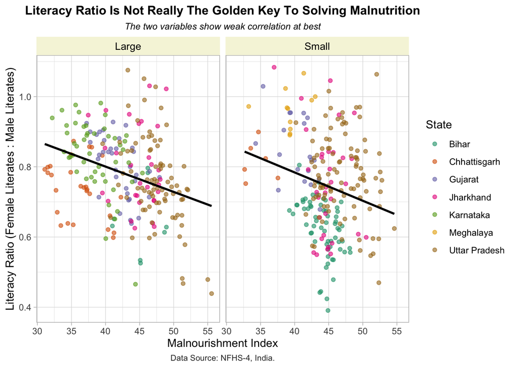

```r
#This code chunk creates a scatter plot for malnutrition and literacy ratio

scatter_ratio <- ggplot(data = combined_data) +
  geom_point(mapping = aes(x = malnourishment_index, y = literacy_ratio, color = state_x), alpha = 0.6) +
  geom_smooth(mapping = aes(x = malnourishment_index, y = literacy_ratio), method = "lm", color = "black", se = FALSE) +  # Line of best fit
 # Apply custom color palette for state names
  facet_wrap(~ district_size) +  # Facet wrap by district size
  theme_light() +
  theme(
    legend.position = "right",
    plot.title = element_text(hjust = 0.5, size = 12, face = "bold"),
    plot.subtitle = element_text(hjust = 0.5, size = 9, face = "italic"),
    plot.caption = element_text(hjust = 0.5, size = 8, color = "gray20"),
    strip.text = element_text(size = 10, color = "black"),  # Adjust text size for facet labels
    strip.background = element_rect(fill = "beige"),
  ) + labs(
    title = "Literacy Ratio Is Not Really The Golden Key To Solving Malnutrition",
    subtitle = "The two variables show weak correlation at best",
    caption = "Data Source: NFHS-4, India.",
    x = "Malnourishment Index",
    y = "Literacy Ratio (Female Literates : Male Literates)",
    color = "State"
  ) +
  scale_color_brewer(palette = "Dark2")

print(scatter_ratio)
```

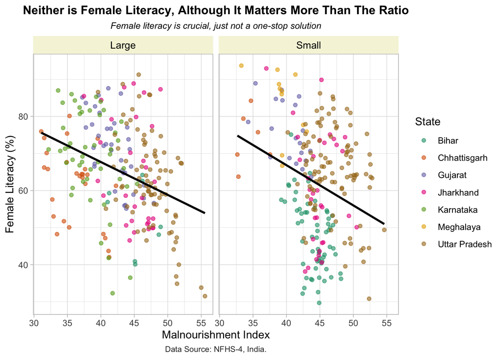

```r
#This code chunk creates a scatter plot for malnutrition and female literacy

scatter_female <- ggplot(data = combined_data) +
  geom_point(mapping = aes(x = malnourishment_index, y = women_who_are_literate_percent, color = state_x), alpha = 0.6) +
  geom_smooth(mapping = aes(x = malnourishment_index, y = women_who_are_literate_percent), method = "lm", color = "black", se = FALSE) +  # Line of best fit
 # Apply custom color palette for state names
  facet_wrap(~ district_size) +  # Facet wrap by district size
  theme_light() +
  theme(
    legend.position = "right",
    plot.title = element_text(hjust = 0.5, size = 12, face = "bold"),
    plot.subtitle = element_text(hjust = 0.5, size = 9, face = "italic"),
    plot.caption = element_text(hjust = 0.5, size = 8, color = "gray20"),
    strip.text = element_text(size = 10, color = "black"),  # Adjust text size for facet labels
    strip.background = element_rect(fill = "beige"),
  ) + labs(
    title = "Neither is Female Literacy, Although It Matters More Than The Ratio",
    subtitle = "Female literacy is crucial, just not a one-stop solution",
    caption = "Data Source: NFHS-4, India.",
    x = "Malnourishment Index",
    y = "Female Literacy (%)",
    color = "State"
  ) +
  scale_color_brewer(palette = "Dark2")

print(scatter_female)
```

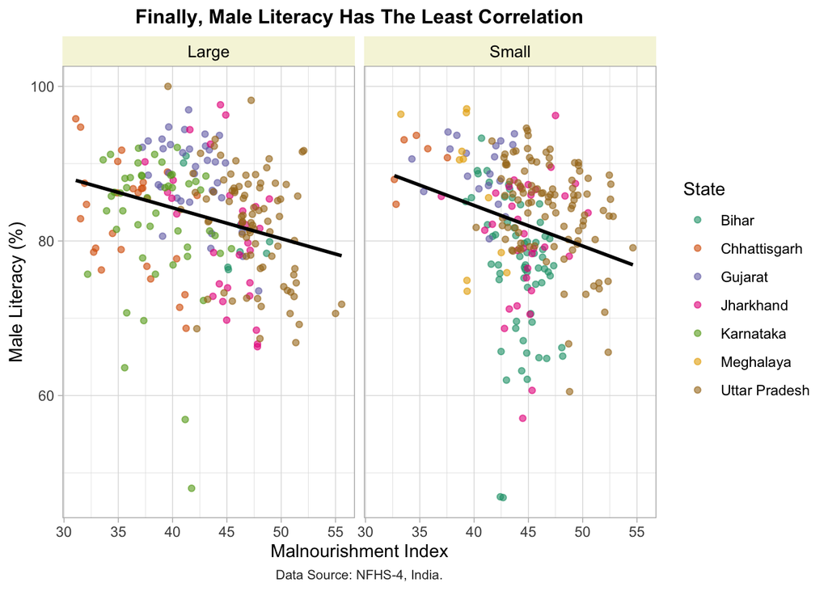

```r
#This code chunk creates a scatter plot for malnutrition and male literacy

scatter_male <- ggplot(data = combined_data) +
  geom_point(mapping = aes(x = malnourishment_index, y = men_who_are_literate_percent, color = state_x), alpha = 0.6) +
  geom_smooth(mapping = aes(x = malnourishment_index, y = men_who_are_literate_percent), method = "lm", color = "black", se = FALSE) +  # Line of best fit
 # Apply custom color palette for state names
  facet_wrap(~ district_size) +  # Facet wrap by district size
  theme_light() +
  theme(
    legend.position = "right",
    plot.title = element_text(hjust = 0.5, size = 12, face = "bold"),
    plot.subtitle = element_text(hjust = 0.5, size = 9, face = "italic"),
    plot.caption = element_text(hjust = 0.5, size = 8, color = "gray20"),
    strip.text = element_text(size = 10, color = "black"),  # Adjust text size for facet labels
    strip.background = element_rect(fill = "beige"),
  ) + labs(
    title = "Finally, Male Literacy Has The Least Correlation",
    caption = "Data Source: NFHS-4, India.",
    x = "Malnourishment Index",
    y = "Male Literacy (%)",
    color = "State"
  ) +
  scale_color_brewer(palette = "Dark2")

print(scatter_male)
```

Numerically, the correlation between malnutrition and literacy rate is about -0.3.

```r
#This code computes the correlation matrix for malnutrition and literacy

cor_data <- combined_data %>%
  select(malnourishment_index, literacy_ratio, women_who_are_literate_percent, men_who_are_literate_percent) %>% st_drop_geometry()

str(cor_data)
```

```
## 'data.frame':    467 obs. of  4 variables:
##  $ malnourishment_index          : num  46.7 46 46.1 46 41 ...
##  $ literacy_ratio                : num  0.565 0.598 0.658 0.644 0.632 ...
##  $ women_who_are_literate_percent: num  36.6 38.8 54.2 54.6 56.9 59.3 42 42.7 50.7 47.3 ...
##  $ men_who_are_literate_percent  : num  64.8 64.9 82.4 84.8 90.1 91 78.4 79.8 75.2 67.1 ...
```

```r
# Calculate the correlation matrix
cor_matrix <- cor(cor_data, use = "complete.obs")
cor_matrix
```

```
##                                malnourishment_index literacy_ratio
## malnourishment_index                      1.0000000     -0.2878902
## literacy_ratio                           -0.2878902      1.0000000
## women_who_are_literate_percent           -0.3313187      0.9134667
## men_who_are_literate_percent             -0.2564978      0.3804845
##                                women_who_are_literate_percent
## malnourishment_index                               -0.3313187
## literacy_ratio                                      0.9134667
## women_who_are_literate_percent                      1.0000000
## men_who_are_literate_percent                        0.7191139
##                                men_who_are_literate_percent
## malnourishment_index                             -0.2564978
## literacy_ratio                                    0.3804845
## women_who_are_literate_percent                    0.7191139
## men_who_are_literate_percent                      1.0000000
```

#### 5.2 Geographically Diverse Determinants

[figure not shown]

```r
#This code chunk creates a map for Meghalaya.

combined_data <- st_as_sf(combined_data) #Converting combined data to an sf dataframe

malnourishment_map_meghalaya <- ggplot(data = combined_data %>% filter(state_x == "Meghalaya")) +
  # Choropleth map: Filling areas based on malnourishment index
  geom_sf(mapping = aes(fill = malnourishment_index), color = "black", size = 0.5) +

  # Bubbles: Representing the percentage of contraceptive usage
  geom_point(aes(x = longitude, y = latitude, size = any_method_percent),
                         alpha = 0.4, color = "black") +

  # Size scale for the bubbles
  scale_size_continuous(range = c(0.1, 3), name = "Female Sterlisation (%)") +

  # Custom color gradient: Low = light yellow, High = dark red
  scale_fill_gradient(low = "#FEBA4F", high = "blue",
                      name = "Malnourishment Index") +

  # Light theme for better readability
  theme_light() +

  # Titles and labels styling
  theme(
    legend.position = "right",
    plot.title = element_text(hjust = 0.5, size = 12, face = "bold"),
    plot.subtitle = element_text(hjust = 0.5, size = 9, face = "italic"),
    plot.caption = element_text(hjust = 0.5, size = 8, color = "gray20")
  ) +

  # Adding titles and caption
  labs(
    title = "Female Sterlisation Can Help Reduce Malnutrition In Meghalaya",
    subtitle = "The two variables showcase a 70% correlation",
    caption = "Data Source: NFHS-4, India & Open Street Maps",
    x = "Longitude",
    y = "Latitude"
  )

print(malnourishment_map_meghalaya)
```

[figure not shown]

```r
#This code chunk creates a map for Bihar

malnourishment_map_bihar <- ggplot(data = combined_data %>% filter(state_x == "Bihar")) +
  # Choropleth map: Filling areas based on malnourishment index
  geom_sf(mapping = aes(fill = malnourishment_index), color = "black", size = 0.5) +

  # Bubbles: Representing the percentage of contraceptive usage
  geom_point(aes(x = longitude, y = latitude, size = any_method_percent),
                         alpha = 0.4, color = "black") +

  # Size scale for the bubbles
  scale_size_continuous(range = c(0.1, 3), name = "Female Sterlisation (%)") +

  # Custom color gradient: Low = light yellow, High = dark red
  scale_fill_gradient(low = "#FEBA4F", high = "blue",
                      name = "Malnourishment Index") +

  # Light theme for better readability
  theme_light() +

  # Titles and labels styling
  theme(
    legend.position = "right",
    plot.title = element_text(hjust = 0.5, size = 12, face = "bold"),
    plot.subtitle = element_text(hjust = 0.5, size = 9, face = "italic"),
    plot.caption = element_text(hjust = 0.5, size = 8, color = "gray20")
  ) +

  # Adding titles and caption
  labs(
    title = "Female Sterlisation Is NOT Reducing Child Malnutrition in Bihar",
    subtitle = "There is, in fact, a positive correlation between the two in the state",
    caption = "Data Source: NFHS-4, India & Open Street Maps",
    x = "Longitude",
    y = "Latitude"
  )

print(malnourishment_map_bihar)
```

## 6. Saving Data

#### 6.1 Saving Files Locally

Overwriting files locally even if they already exist to account for any changes that are required to be made.

```r
#This code chunk saves over all the previously saved files to the local computer at each step of the report. This is done in order to ensure that any changes made to the code are not lost.
#The eval here is set to FALSE so that the code does not run without the reader setting desired directory.

primary_data_path <- file.path(tidy_data_dir, paste0("Primary data.csv")) #Saving file path for tidy primary data.
secondary_data_path <- file.path(tidy_data_dir, paste0("Secondary_data.geojson")) #Saving file path for seconadry spatial data.
spatial_data_path <- file.path(raw_data_dir, paste0("spatial_data_raw.RData")) #Saving file path for raw spatial list.
transformed_primary_data_path <- file.path(processed_data_dir, paste0("Transformed_primary_data.csv")) #Saving file path for transformed primary data.
transformed_secondary_data_path <- file.path(processed_data_dir, paste0("Transformed_secondary_data.geojson")) #Saving file path for transformed secondary data.
combined_data_path <- file.path(processed_data_dir, paste0("Combined_data.geojson")) #Saving file path for combined.

write_csv(primary_data, primary_data_path) #Saving primary data.
write_rds(spatial_list, spatial_data_path) #Saving the raw spatial list.
st_write(secondary_data, secondary_data_path, driver = "GeoJSON") #Saving secondary data as a shapefile.
write_csv(transformed_primary_data, transformed_primary_data_path) #Saving transformed primary data
st_write(transformed_secondary_data, transformed_secondary_data_path, drivers = "GeoJSON") #Saving transformed secondary data
st_write(combined_data, combined_data_path, drivers = "GeoJSON") #Saving combined data
ggsave(filename = "scatter_ratio.png", path = output_dir, plot = scatter_ratio) #Saving scatterplot
ggsave(filename = "scatter_female.png", path = output_dir, plot = scatter_female) #Saving scatterplot
ggsave(filename = "scatter_male.png", path = output_dir, plot = scatter_male) #Saving scatterplot
ggsave(filename = "malnourishment_map_bihar.png", path = output_dir, plot = malnourishment_map_bihar) #Saving map
ggsave(filename = "malnourishment_map_meghalaya.png", path = output_dir, plot = malnourishment_map_meghalaya) #Saving map

#The reader is requested to run this chunk to overwrite saved data, save new data or after setting directory.
```

#### 6.2.1 Saving Tabular Data IN SQL Database

Saving tables in SQL is directly done by writing the tables to the connected database.

```r
#This code connects to an SQL database and saves all the tables in the SQL database.

dbWriteTable(cmi, "Primary Data", primary_data, overwrite = TRUE) #Saving primary data table in SQL database
dbWriteTable(cmi, "Transformed Primary Data", transformed_primary_data, overwrite = TRUE) #Saving transformed primary data table in SQL database
st_write(secondary_data, cmi, "geometry", append = FALSE, delete_layer = TRUE) #Saving transformed secondary data geoJson in SQL database
st_write(transformed_secondary_data, cmi, "geometry", append = FALSE, delete_layer = TRUE) #Saving transformed secondary data geoJson in SQL database
st_write(combined_data, cmi, "geometry", append = FALSE, delete_layer = TRUE) #Saving combined data geoJson in SQL database

#Saving data to database
dbWriteTable(cmi, "Uttar Pradesh", uta, overwrite = TRUE)
dbWriteTable(cmi, "Bihar", bih, overwrite = TRUE)
dbWriteTable(cmi, "Jharkhand", jha, overwrite = TRUE)
dbWriteTable(cmi, "Meghalaya", meg, overwrite = TRUE)
dbWriteTable(cmi, "Gujarat", guj, overwrite = TRUE)
dbWriteTable(cmi, "Karnataka", kar, overwrite = TRUE)
dbWriteTable(cmi, "Chhattisgarh", chh, overwrite = TRUE)
dbWriteTable(cmi, "Uttar Pradesh Tidy", uta_tidy, overwrite = TRUE)
dbWriteTable(cmi, "Bihar TIdy", bih_tidy, overwrite = TRUE)
dbWriteTable(cmi, "Jharkhand Tidy", jha_tidy, overwrite = TRUE)
dbWriteTable(cmi, "Meghalaya Tidy", meg_tidy, overwrite = TRUE)
dbWriteTable(cmi, "Gujarat Tidy", guj_tidy, overwrite = TRUE)
dbWriteTable(cmi, "Karnataka Tidy", kar_tidy, overwrite = TRUE)
dbWriteTable(cmi, "Chhattisgarh Tidy", chh_tidy, overwrite = TRUE)
```

#### 6.2.2 Saving Non- Tabular Data IN SQL Database

Saving non-tabular data in SQL can only be done in the form of binary values.

```r
#This code chunk saves raw RDS data and Image output in SQL as BLOBs.
#The echo is set to FALSE here since the code chunk outputs 0 and 1 message from the database.

dbExecute(cmi, "
  CREATE TABLE IF NOT EXISTS non_tabular_data (
      id INTEGER PRIMARY KEY AUTOINCREMENT,
      file_name TEXT,
      file_type TEXT NOT NULL,
      file_data BLOB
  )
") #Creating table to save BLOB data

read_file_as_raw <- function(file_path) { #Setting function to read in image and rds data and then convert them to BLOB (binary data).
  raw_data <- readBin(file_path, what = "raw", n = file.info(file_path)$size) #reading in raw data
  return(raw_data)}

save_file_to_db <- function(file_path, file_type) { #Setting function to save data to database.
  file_data <- read_file_as_raw(file_path) #Using read_file_as_raw function within the current function to read in the data
  file_name <- basename(file_path) #Extracting file name

  dbExecute(cmi, "
    INSERT INTO non_tabular_data (file_name, file_type, file_data) VALUES (?, ?, ?)",
    params = list(file_name, file_type, list(file_data))) #Inserting file into databse
}

save_rds_to_db <- function(rds_path) { #Setting function to save rds file
  save_file_to_db(rds_path, 'rds') #Using save_file_to_db within current function
}

save_png_to_db <- function(png_path) { #Setting function to save png file
  save_file_to_db(png_path, 'png') #Using save_file_to_db within current function
}

save_rds_to_db(spatial_data_path) #Actually saving rds file

plot_list <- list("scatter_ratio", "scatter_female", "scatter_male", "malnourishment_map_bihar", "malnourishment_map_meghalaya") #Creating a list of plots created.

for (i in plot_list){ #Initialising loop to save each of the png plots
  plot_path <- file.path(output_dir, paste0(i, ".png"))
  save_png_to_db(plot_path)}  #Actually saving png file
```

Word Count: 971